# Explore famous psychological schools

Jiahao Shao

2022/2/1

*The ultimate value of life depends upon awareness and the power of contemplation rather than upon mere survival.*

*By Aristotle*

The above quote is said by Aristotle, a well-known Greek philosopher and polymath in Ancient Greek. He has achievements in many fields, like math, physics, and especially, philosophy. He explored the relationship between humans and nature. Aristotle’s works and the philosophy school of Aristotle shaped centuries of philosophy from Late Antiquity through the Renaissance, and even today continue to be studied with ardent interest.[1]

[figure not shown]

Then we want to take a deeper look at the sentences Aristotle said and find the most frequent words he has mentioned. Here we would use a dataset from Philosophy Data Project.[3] The dataset contains over 300,000 sentences from over 50 texts spanning ten major schools of philosophy, including Aristotle. We import the dataset, do the data cleaning, ignore the punctuation as well as some common words, and finally, make a word cloud.

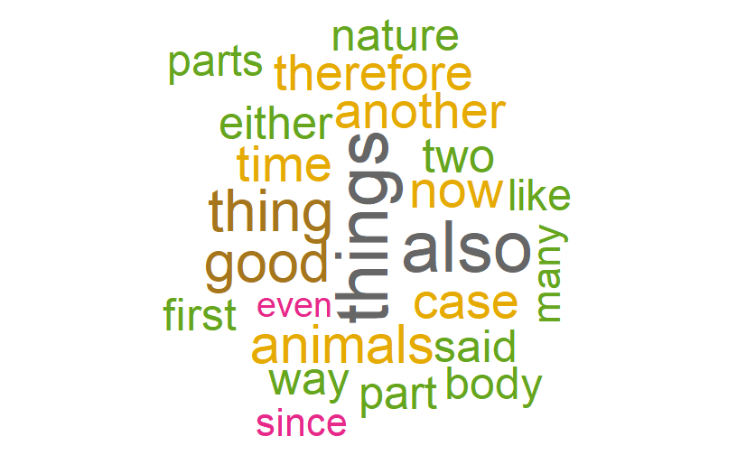

Next, we will do something more interesting. Let’s talk about the word frequency of two most well-known schools, *Communism* and *Capitalism*.

Let’s begin with *Communism* :

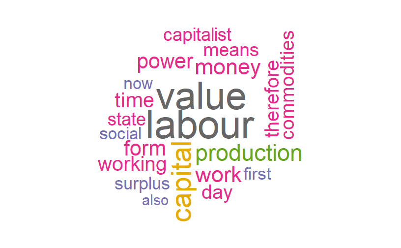

Here is the word cloud for Communism. The figure is much different than the last one. Not surprisingly, “labour” is the biggest word, meaning that the communists mentioned this word more than any other word. We all know that Communists care about labor, and the figure shows the pattern.

Then, let’s see the word cloud for *Capitalism* :

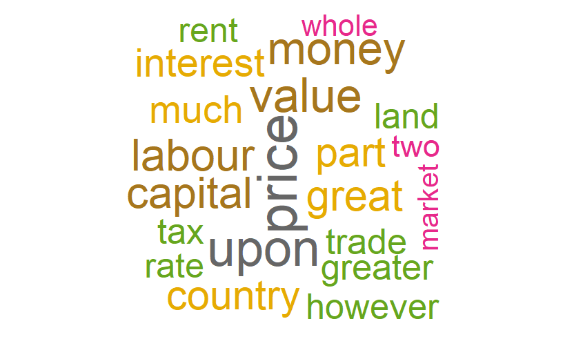

Finally, I’ll leave a word cloud for continental philosophy, which had been prevalent from the early 20th century in England and later in other English-speaking countries. Can you find anything interesting from the graph? Leave a comment about what you found!

*Continental* :

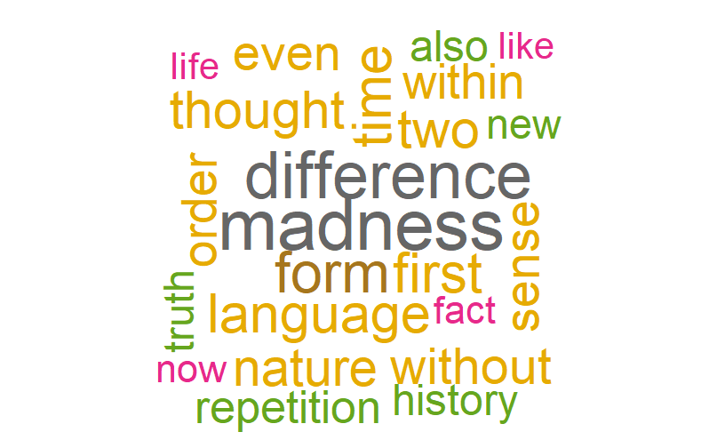

*Reference*

[1] Malpas, J., Donald Davidson, The Stanford Encyclopedia of Philosophy (Winter 2012 Edition), Edward N. Zalta (ed.), URL = https://plato.stanford.edu/archives/win2012/entries/davidson/.

[2] picture from: https://upload.wikimedia.org/wikipedia/commons/a/ae/Aristotle_Altemps_Inv8575.jpg.

[3] dataset from: https://www.kaggle.com/kouroshalizadeh/history-of-philosophy